# Workshop 3: Metagenome Assembly

Jake Davis

2026-11-22

Notes for [Workshop 3](https://mb5370.bioinformatics.guide/workshop3.html). Run the commands for this workshop in the Terminal, from inside the folder named under each heading. Copy each command you run into a bash chunk.

R chunks in this file run from the top of the repository, so give file paths from there, e.g. `flye_metagenome/mock/assembly_info.txt`.

## Step 1: Examine reads

The metagenomic sequencing data were provided as a compressed FASTQ file. I created a symbolic link to access the original dataset without duplicating it.

```bash
cd ~/mb5370-workshops/raw_data
ln -s /pvol/data/metagenome_assembly/reads_R10_0.5.fastq.gz raw_reads.fastq.gz
cd ..

zcat raw_data/raw_reads.fastq.gz | head -n 8
```

### Observations

The first two reads were 5,573 bp and 10,520 bp long, with reported sequence identities of 89.41% and 93.61%, respectively.

The FASTQ records contained nucleotide sequences and corresponding quality scores, with matching sequence and quality-score lengths.

### Read length distribution

I examined the length distribution of the first 10,000 sequencing reads.

### Extract read lengths

I extracted the lengths of the first 10,000 sequencing reads for analysis in R.

```bash
cd ~/mb5370-workshops
zcat raw_data/raw_reads.fastq.gz | head -n 40000 | bioawk -c fastx '{print $name,length($seq)}' > read_lengths.txt
wc -l read_lengths.txt
```

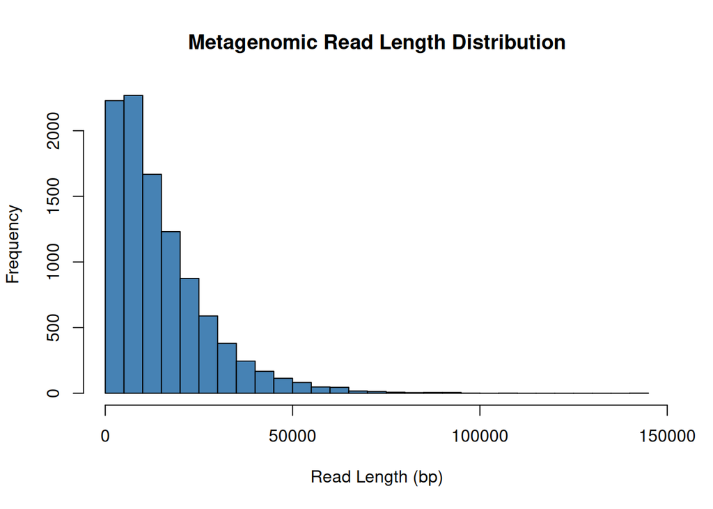

```r
reads <- read.table(
  "read_lengths.txt",
  header = FALSE,
  col.names = c("read_id", "length")
)

hist(
  reads$length,
  breaks = 50,
  col = "steelblue",
  main = "Metagenomic Read Length Distribution",
  xlab = "Read Length (bp)",
  ylab = "Frequency"
)
```

```r
summary(reads$length)
```

```
##    Min. 1st Qu.  Median    Mean 3rd Qu.    Max.
##      17    5537   11394   14893   20480  140564
```

### Interpretation

The read-length distribution was strongly right-skewed, with most sequencing reads shorter than approximately 30,000 bp. Read frequency decreased as sequence length increased, although a small number of reads extended beyond 100,000 bp.

This variation in read length is characteristic of long-read sequencing datasets. Longer reads can help resolve repetitive regions during genome assembly.

### Read N50

```r
sorted_lengths <- sort(reads$length, decreasing = TRUE)
read_n50 <- sorted_lengths[
  which(cumsum(sorted_lengths) >= sum(sorted_lengths) / 2)[1]
]

read_n50
```

```
## [1] 22322
```

## Step 2: Metagenome Assembly

I used Flye in metagenome mode to assemble the simulated long-read sequencing dataset. The assembly was submitted to the JCU computing server using Slurm.

```bash
cd ~/mb5370-workshops/flye_metagenome
sbatch run_flye.sh
```

The assembly was submitted as Slurm job 728 using four CPU cores and 6 GB of allocated memory.

The Flye command is stored in `run_flye.sh` and uses the `--meta` option for metagenomic assembly.

Assembly results will be evaluated after the job finishes.

## Step 3: Basic assembly QC

After Flye completes, I will examine the assembled contigs to assess the overall quality and structure of the metagenome assembly.

The main metrics of interest are the number of contigs, total assembly length, and N50. These provide an indication of assembly continuity, although they do not independently establish genome completeness or accuracy.

### Reference genome GC content

I used `bioawk` and a custom AWK script to calculate the length and GC proportion of the supplied bacterial reference sequences.

```bash
cd ~/mb5370-workshops
cat /pvol/data/mg/refs/*.fna | bioawk -c fastx -f gc.awk
```

The reference sequences varied considerably in length and GC content. The observed GC proportions ranged from approximately 34.6% to 63.6%.

These differences may help distinguish genomic sequences during metagenomic analysis, although GC content alone is insufficient to identify bacterial species.

### Assembly statistics

The Flye metagenome assembly produced 42 contigs totaling 18,367,642 bp. The largest contig was 4,681,066 bp.

```r
assembly <- read.table(
  "flye_metagenome/mock/assembly_info.txt",
  header = FALSE,
  skip = 1
)

lengths <- sort(assembly$V2, decreasing = TRUE)

assembly_n50 <- lengths[
  which(cumsum(lengths) >= sum(lengths) / 2)[1]
]

assembly_n50
```

```
## [1] 1842109
```

### Interpretation

The Flye metagenome assembly produced 42 contigs totaling 18.37 Mb, with an N50 of 1.84 Mb. This indicates that a substantial proportion of the assembled sequence is contained in relatively long contigs. However, assembly continuity alone does not establish genome completeness or accuracy.

## Step 4: Binning

I used MetaBAT2 to group assembled contigs into potential bacterial genome bins based on sequence coverage and composition.

```bash
cd ~/mb5370-workshops/metabat
mkdir -p bins

grep -v '#' ../flye_metagenome/mock/assembly_info.txt | awk '{OFS="\t"; print $1,$3}' > depths.txt

awk '{print $1}' depths.txt | xargs samtools faidx ../flye_metagenome/mock/assembly.fasta > assembly_ordered.fasta

metabat2 -i assembly_ordered.fasta -a depths.txt --cvExt -o bins/metabat --seed 5
```

### Binning results

MetaBAT2 generated seven genome bins containing approximately 13.46 Mb of assembled sequence.

The largest assembled contig, `contig_42` (4,681,066 bp), was not assigned to any bin. I extracted it separately for subsequent quality assessment.

```bash
samtools faidx ../flye_metagenome/mock/assembly.fasta contig_42 > bins/unbinned_contig_42.fa
```

Although the simulated metagenome contains five bacterial species, the seven bins do not necessarily represent seven distinct organisms. Genome completeness and contamination must be assessed before interpreting them.

## Step 5: Bin Quality Assessment with CheckM

I used CheckM to evaluate the completeness and contamination of the genome bins generated by MetaBAT2.

Seven MetaBAT2 bins and the separately extracted `contig_42` were included in the assessment.

```bash
cd ~/mb5370-workshops/checkm
sbatch run_checkm.sh
```

CheckM was submitted through Slurm as job 729, requesting four CPU cores and 40 GB of memory.

### Results and Interpretation

CheckM evaluated seven MetaBAT2 genome bins and the separately extracted largest contig (`contig_42`).

```r
checkm_summary <- data.frame(
  Genome = c(
    "unbinned_contig_42", "metabat.7", "metabat.6",
    "metabat.4", "metabat.3", "metabat.5",
    "metabat.1", "metabat.2"
  ),
  Completeness = c(99.87, 99.72, 67.68, 18.26,
                   18.18, 12.50, 7.48, 0.00),
  Contamination = c(0.71, 0.85, 0.00, 0.00,
                    0.00, 0.00, 0.00, 0.00)
)

knitr::kable(
  checkm_summary,
  col.names = c("Genome", "Completeness (%)", "Contamination (%)")
)
```

| Genome | Completeness (%) | Contamination (%) |
| --- | --- | --- |
| unbinned_contig_42 | 99.87 | 0.71 |
| metabat.7 | 99.72 | 0.85 |
| metabat.6 | 67.68 | 0.00 |
| metabat.4 | 18.26 | 0.00 |
| metabat.3 | 18.18 | 0.00 |
| metabat.5 | 12.50 | 0.00 |
| metabat.1 | 7.48 | 0.00 |
| metabat.2 | 0.00 | 0.00 |

Two genome candidates showed particularly high estimated quality: `unbinned_contig_42` (99.87% completeness, 0.71% contamination) and `metabat.7` (99.72% completeness, 0.85% contamination).

Notably, the largest assembled contig was not assigned to a MetaBAT2 bin, despite showing high estimated completeness. This highlights a limitation of automated genome binning.

The remaining bins showed lower estimated completeness, including several highly incomplete genome candidates. Consequently, these bins would require additional evaluation before being treated as reliable reconstructed genomes.

Overall, the workflow demonstrates how metagenomic assembly, binning, and genome-quality assessment can be combined to recover and evaluate potential microbial genomes.